# Is there a wage gap between genders?

Final Project for Coding 1: Data Management and Analysis with R

Agnes Nagy

January 03, 2021

Abstract

We are interested in changes in wage followed by increased level of experience and education. This relationship will be examined by gender in order to access whether the extra effort in education or an increased experience level was rewarded in the same way in 1982.

# Our Data

The data analysed comprises of 595 yearly salary data along with key personal and professional data such as marrage status, gender, weeks worked, education and experience in years as well as if they work as blue or white collar workers. Some extreme values were ommited, observations with over 100 dollars weekly wage and education level under 10 years. Weekly wages were calculated in order to obtain a better comparison base.

Wage information from both Southern (blue) and Northern (grey) US was collected.

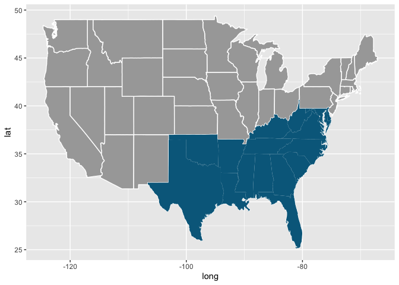

Variables summary - Education and experience

| Variable | Mean | Median | Min | Max |
| --- | --- | --- | --- | --- |
| Experience | 22.07 | 20 | 7 | 46 |
| Education | 13.49 | 12 | 10 | 17 |

As presented by the below barcharts, we can see that the dataset consisted of mainly married people working as both blue and white collar workers. As shown by the plot to the right below, the data on female and male workers is not balanced, serving as one of the main limitations of our analysis - more observations on female wages would be needed in order to make a conclusive summary.

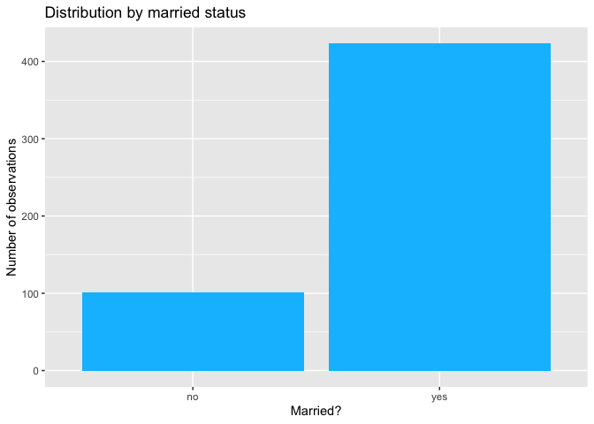

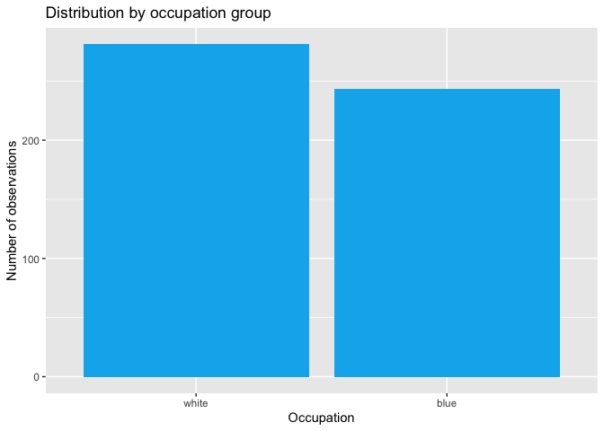

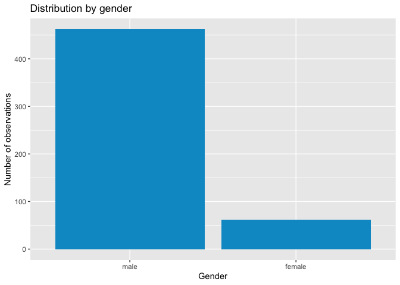

# Our analysis of wage changes

There is positive relationship between weekly wages and experience as well as weekly wages and education for both genders. The below two charts presents clearly that female weekly wages are lower for the same education level and experience level.

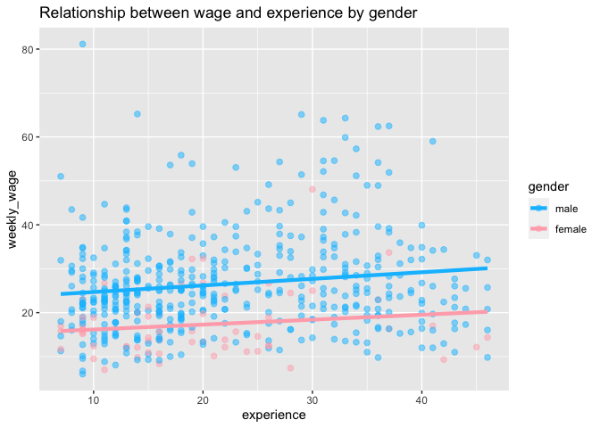

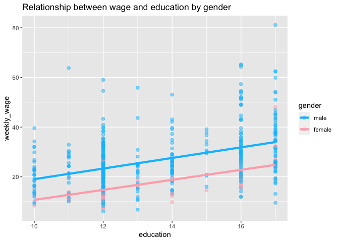

A more detailed analysis was carried out in order to be able to examine the relationship between weekly wages, experience and education. Observations were grouped together based on years of experience to see if this gap changes between groups. As presented by the belo charts, we can see that this gap closes within the 30-40 years of experience indicating that those having more experience can expext similar wages regardless the gender, given the same education level. Please note however that these closing scrissors cannot be observed for group of observations over 40 years, indocating that this might be an erroneous assumption.

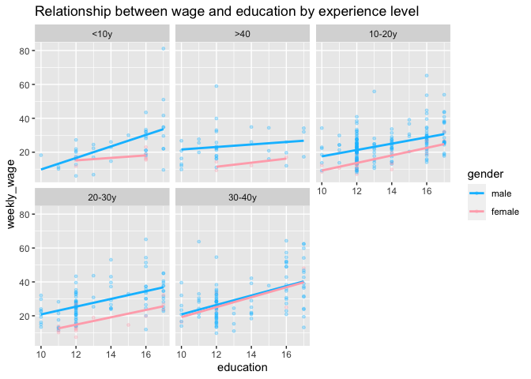

# Our Model

Both level level and log level transformation models were examined in connection to the relationship between wages (both genders together) and education / experience to understand the relationship better. As a result we understand that the most suitable analysis relates to regressing experience and education on log-wages. This suggests that without controlling other variables, 1 unit increase in education / experience (years) indicates a higher % change in weekly wages.

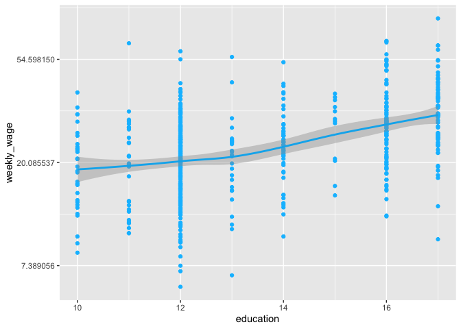

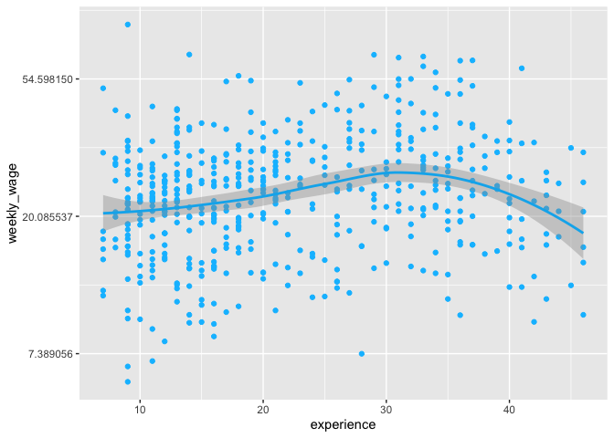

[output not shown]

[output not shown]

# Summary

The present paper intended to see whether there is a wage gap relating to genders based on data from the United States in 1982. We have used plots to see the relationship between education / experience and weekly wages as well as log level model to understand and explain the data selected. The given dataset concludes that female workers with the same years of education and experience were not rewarded the same as their male co-workers. Some data indicates that this wage gap is narrowed down with the years of experience increasing, however no conclusing evidence was found.

# Appendix

The below charts present the weekly wages (for both genders together) in relation to education and experience:

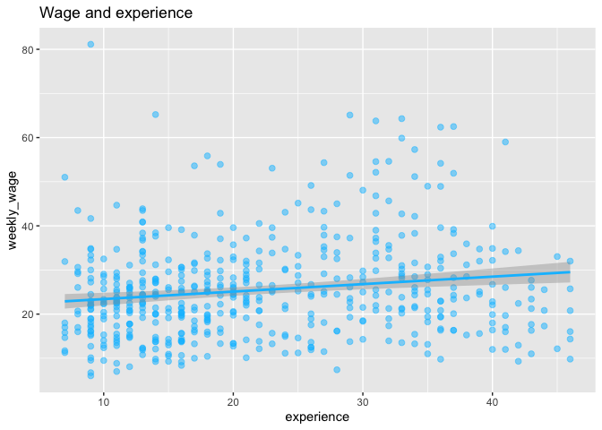

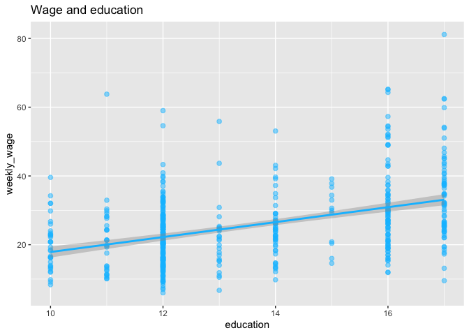

The model not chosen to be analysed, level level transformation is presented below:

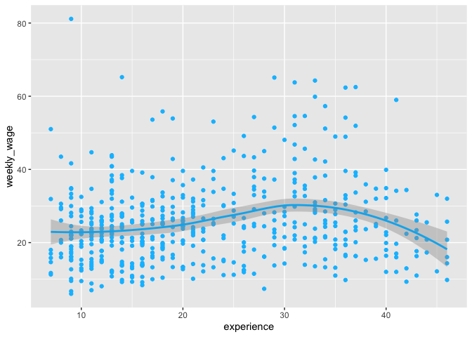

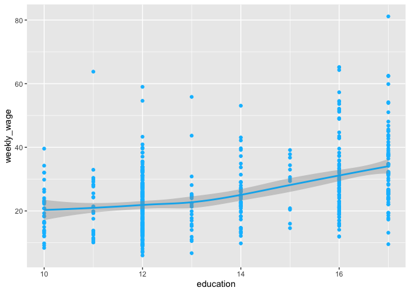

```
##
## Call:
## lm(formula = weekly_wage ~ experience, data = PSID1982)
##
## Residuals:
##     Min      1Q  Median      3Q     Max
## -19.702  -7.785  -1.336   4.975  57.905
##
## Coefficients:
##             Estimate Std. Error t value Pr(>|t|)
## (Intercept) 21.70969    1.11400  19.488  < 2e-16 ***
## experience   0.16949    0.04558   3.719 0.000222 ***
## ---
## Signif. codes:  0 '***' 0.001 '**' 0.01 '*' 0.05 '.' 0.1 ' ' 1
##
## Residual standard error: 10.96 on 522 degrees of freedom
## Multiple R-squared:  0.02581,    Adjusted R-squared:  0.02394
## F-statistic: 13.83 on 1 and 522 DF,  p-value: 0.000222
```

```
##
## Call:
## lm(formula = weekly_wage ~ education, data = PSID1982)
##
## Residuals:
##     Min      1Q  Median      3Q     Max
## -23.540  -6.926  -1.167   4.845  48.058
##
## Coefficients:
##             Estimate Std. Error t value Pr(>|t|)
## (Intercept)  -3.8448     2.7092  -1.419    0.156
## education     2.1722     0.1982  10.957   <2e-16 ***
## ---
## Signif. codes:  0 '***' 0.001 '**' 0.01 '*' 0.05 '.' 0.1 ' ' 1
##
## Residual standard error: 10.01 on 522 degrees of freedom
## Multiple R-squared:  0.187,  Adjusted R-squared:  0.1854
## F-statistic: 120.1 on 1 and 522 DF,  p-value: < 2.2e-16
```